# Day 2

Dec 4, 2018

## Outline

- Basic statistical analysis
  - descriptive statistics
  - hypothesis test
- We first introduce the concept, then we will practise with a real dataset

## Descriptive Statistics

Statistics that describe your data

- summarize the data and turn data into information
- it is basically the first thing you need to do when you have nothing know for the data

## Numeric data

- measurement of locations
  - mean
  - median
  - quantiles/percentiles

mean: \(\frac{1}{n}\sum_i^n x_i\)

median and quantiles are special scenarios of percentiles.

- order the data points (from minimal to maximal)
- the k^th percentile is defined as the `k/100*(n-1) + 1` value
- median the 50^th percentile
- quantile:
  - the minimal
  - Q1 the 25^th percentile, the first quantile
  - Q2 the median, the second quantile
  - Q3 the 75^th percentile, the third quantile
  - the maximal

What if `i = k/100*(n-1) + 1` is not an integer?

- take the integer which is closest to `i`
- take the mean of `floor(i)` and `celing(i)` (the left and right integers)
- take the mean of `floor(i)` and `celing(i)` by weighting the distance (linearly interpolation)

assume the following vector that has been sorted:

```
1  2  3  4  5  6  7  8  9 10  11  value vector
0 10 20 30 40 50 60 70 80 90 100  percentile
    ~ <-
```

the 12^th percentile (i = 12/100*(11-1) + 1 = 2.2)

- 2
- 2.5
- 2 + 0.2*(3-2) = 2.2

```r
quantile(1:11, p = 0.12)
```

```
## 12%
## 2.2
```

R functions to get descriptive statistics:

```r
set.seed(123456)
x = rnorm(100)  # sample 100 random data points from standard normal distribution
mean(x)
```

```
## [1] 0.01681979
```

```r
median(x)
```

```
## [1] 0.04790734
```

```r
quantile(x)
```

```
##          0%         25%         50%         75%        100%
## -2.74886838 -0.72599751  0.04790734  0.83391491  2.50264541
```

```r
quantile(x, p = c(0.05, 0.95))  # percentiles
```

```
##        5%       95%
## -1.564047  1.538384
```

mean and median are very close for symmetric distribution.

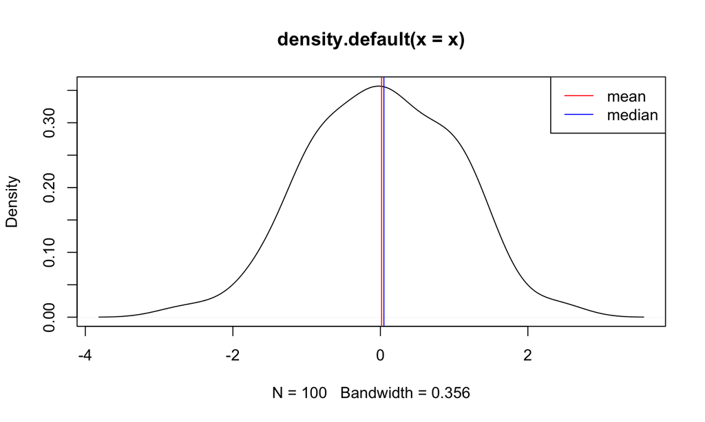

mean and median can be far from each other for non-symmetric distributions.

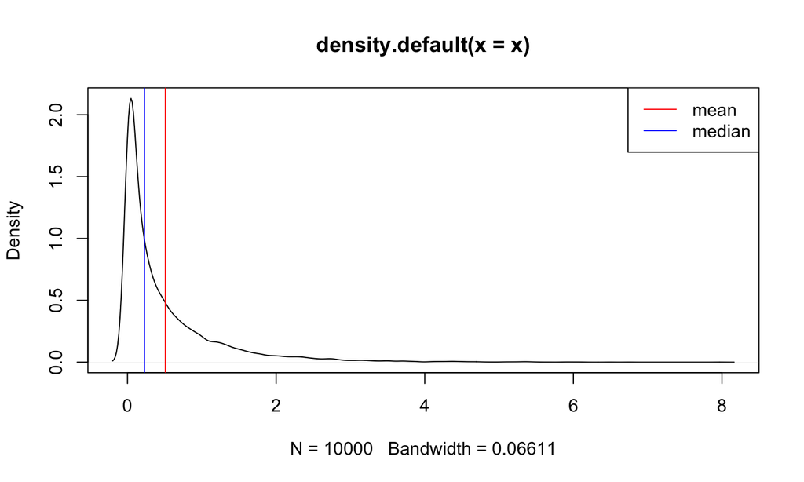

## Numeric data

- measurement of dispersion
  - Range
  - Interquartile range
  - Variance/Standard Deviation
  - Coefficient of Variation

Range is simply \(max - min\)

```r
x = rnorm(100)
range(x) # minimal and maximal
```

```
## [1] -2.558968  3.078589
```

Interquartile range (IQR) is Q3 - Q1 (75^th percentile - 25^percentile)

```r
quantile(x, 0.75) - quantile(x, 0.25)
```

```
##     75%
## 1.25958
```

```r
IQR(x)
```

```
## [1] 1.25958
```

Variance and standard deviation

\(var = \frac{1}{n}\sum(x - \mu)^2\)

\(sd = \sqrt{var}\)

```r
var(x)
```

```
## [1] 1.181237
```

```r
sd(x)
```

```
## [1] 1.086847
```

Coefficient of Variation (CV)

dispersion relative to the level of the data

```r
sd(x)/mean(x)
```

```
## [1] 40.43593
```

## Visualize the descriptive statistiics

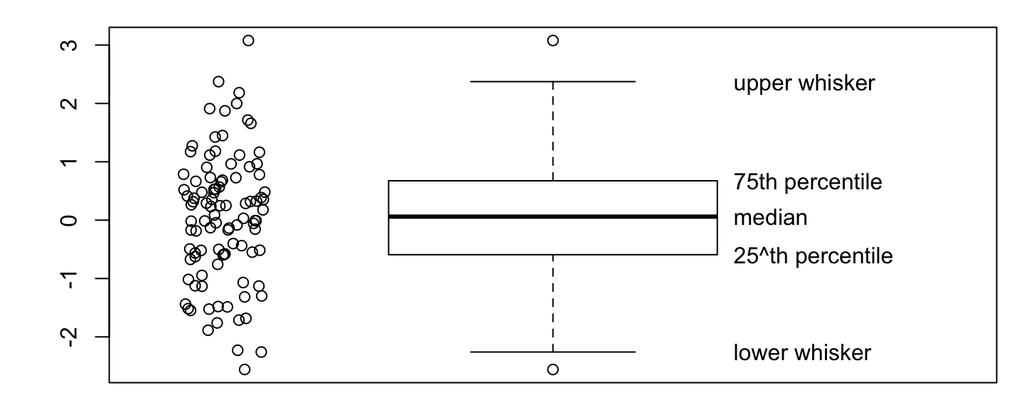

```r
boxplot(x)
```

- lower wisker is the minimal value >= Q1 - 1.5*IQR
- upper wisker is the maximal value <= Q3 + 1.5*IQR
- values outside of the wiskers are outliers

## scale your data

With descriptive statistics, we can scale our data.

- make vectors comparable (in a same scale)
- some analysis needs the data to be scaled

```r
x1 = rnorm(10, mean = 4, sd = 3)
x2 = rnorm(10, mean = -1, sd = 1)
```

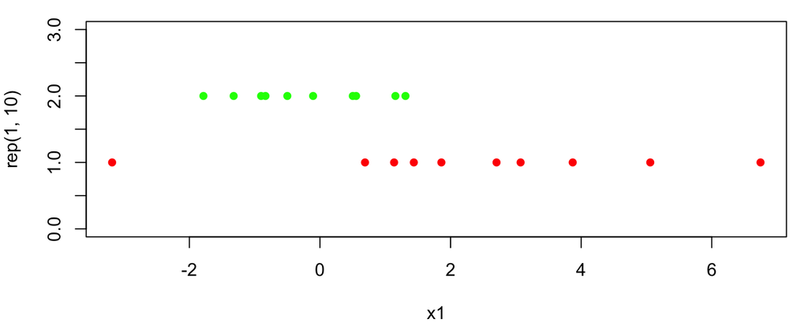

z-score scaling

\(x' = \frac{x - \mu}{\sigma}\)

- mean is enforced to be zero
- sd is enforced to be 1

```r
y1 = (x1 - mean(x1))/sd(x1)
y2 = (x2 - mean(x2))/sd(x2)
```

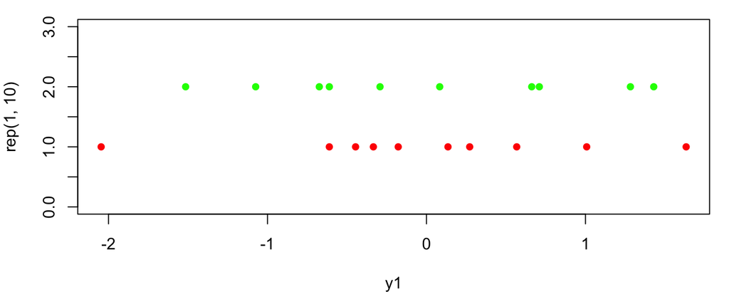

standardization

\(x' = frac{x - min}{max - min}\)

```r
y1 = (x1 - min(x1))/(max(x1) - min(x1))
y2 = (x2 - min(x2))/(max(x2) - min(x2))
```

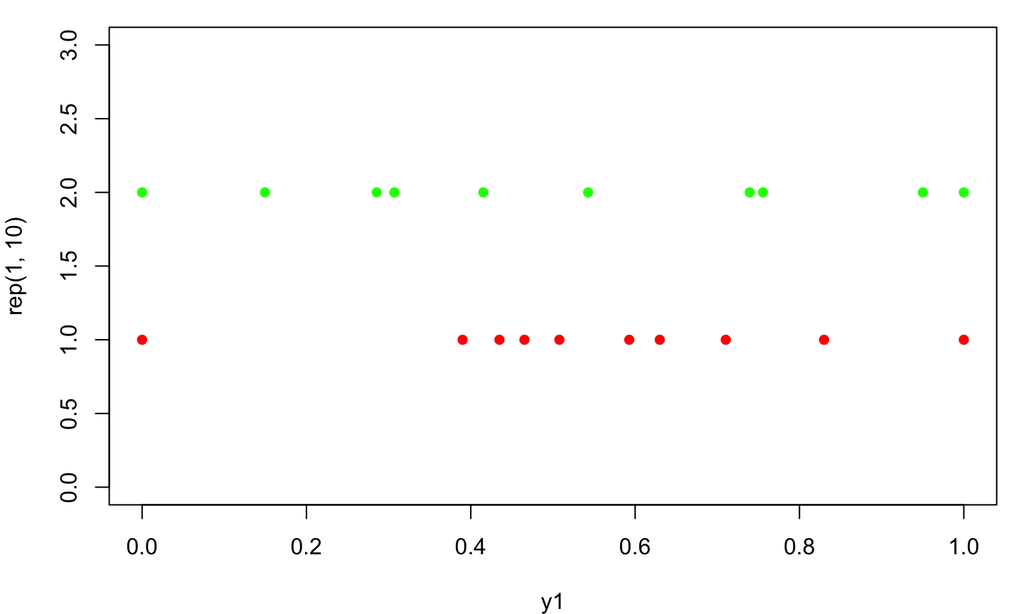

## Making distributions

Besides the descriptive statistics, we always need to make the distribution to see what exactly the data looks like.

Histogram is a frequency-based approach

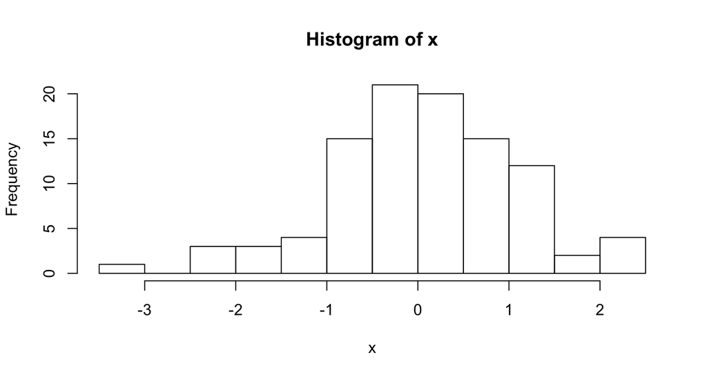

```r
x = rnorm(100)
hist(x)
```

Density is a more exact way to estimate the real distribution based on `x` ( assume `x` is a small sample from the population)

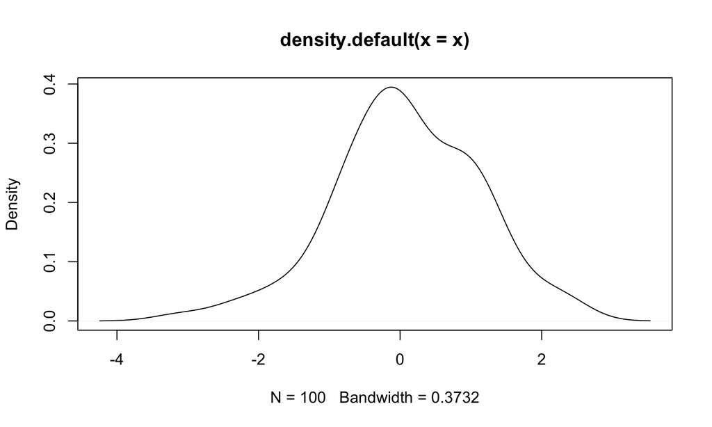

```r
plot(density(x))
```

## correlation

- Pearson correlation
- Spearman correlation (rank-based correlation)

```r
x = runif(10)
y = x + rnorm(10, sd = 0.5)
cor(x, y)
```

```
## [1] 0.5968809
```

```r
cor(x, y, method = "spearman")
```

```
## [1] 0.430303
```

It is always a good idea to plot the correlation.

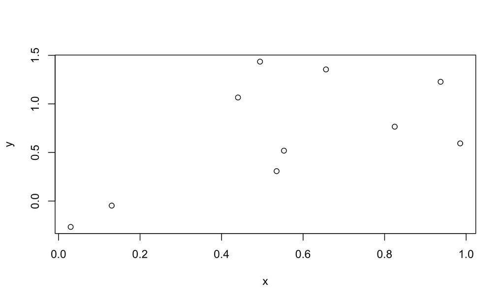

```r
plot(x, y)
```

Spearman correlation is good at non-linear correlation

```r
x = runif(10, max = 5)
y = x^10
cor(x, y)
```

```
## [1] 0.7438561
```

```r
cor(x, y, method = "spearman")
```

```
## [1] 1
```

Spearman correlation is robust to outliers

```r
set.seed(1234)
x = runif(10); x[10] = 100
y = runif(10); y[10] = 100
cor(x, y)
```

```
## [1] 0.9999322
```

```r
cor(x, y, method = "spearman")
```

```
## [1] 0.3212121
```

```r
cor(x[1:9], y[1:9])
```

```
## [1] 0.06834788
```

```r
cor(x[1:9], y[1:9], method = "spearman")
```

```
## [1] 0.06666667
```

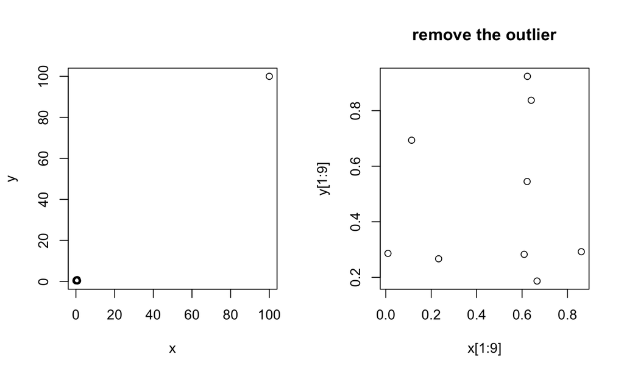

```r
par(mfrow = c(1, 2))
plot(x, y)
plot(x[1:9], y[1:9], main = "remove the outlier")
```

## outliers

Outlier is a basic problem in data anlaysis, but in most cases, people ignore it.

Following statistics are significantly affected by outliers:

- mean/var/sd/cv/range/z-score scaling/Pearson correlation

Following statistics are robust to outliers:

- median/percentiles/IQR/Spearman correlation

## Hypothesis tests

two-sample test

Why do we need to do test?

- the data points are just a small portion of data that are sampled from the population, and we don't know how much it can or can not represent the population. The test can tell us the probability of correctly make our conclusions.

## t-test

parameteric test

- Data must follow normal distribution (why it is called parametric)

Main steps:

- a statistic for which the test is applied on
- null hypothesis H0 (something we want to reject)
- alternative hypothesis H1 (something makes sense to us)

the test gives you a probability of "rejecting H0" is wrong.

Assume `x1` and `x2` are from normal distribution, the t-statistic is defined as

\(t = \frac{\bar{X}_1 - \bar{X}_2}{s_p\sqrt{\frac{2}{n}}}\)

\(s_p = \sqrt{\frac{s^2_{X_1}+s^2_{X_2}}{2}}\)

t-statistic follows a t-distribution and we can calculate

P(T >= |t|)

Apply two-sample t-test with `t.test()` function.

```r
x1 = rnorm(10, mean = -1)
x2 = rnorm(10, mean = 1)
t.test(x1, x2)
```

```
##
##  Welch Two Sample t-test
##
## data:  x1 and x2
## t = -4.349, df = 15.086, p-value = 0.0005654
## alternative hypothesis: true difference in means is not equal to 0
## 95 percent confidence interval:
##  -2.5777800 -0.8826677
## sample estimates:
##  mean of x  mean of y
## -1.1181707  0.6120532
```

Boxplot can be used to visualize the difference:

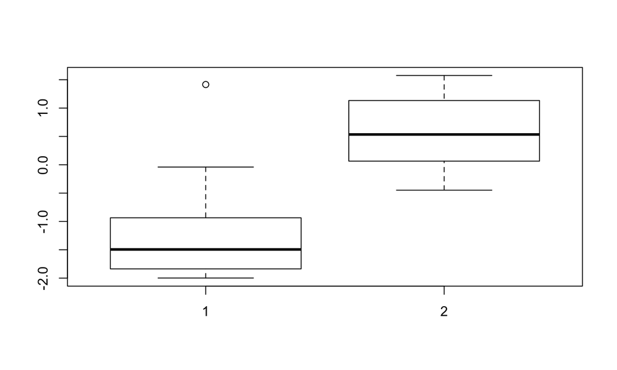

```r
boxplot(list(x1, x2))
```

## rank-based test

non-parametric test

- no assumption of the distribution of the data
- data points reduced to rank
- still there is approximation of the distribution of the statisitcs

`wilcox.test()` function:

```r
wilcox.test(x1, x2)
```

```
##
##  Wilcoxon rank sum test
##
## data:  x1 and x2
## W = 9, p-value = 0.00105
## alternative hypothesis: true location shift is not equal to 0
```

## permutation-based test

It complete learns from the data.

- still need a statistic (the design of the statistic won't affect p-value too much)

steps are:

- design a statistic, e.g. mean difference s0 = |mean(x1) - mean(x2)|
- pool `x1` and `x2` and random 10 data points for each of the two groups, and calculate s0_random for this random dataset
- repeat for 1000 times and we have 1000 s0_random values
- the p-value is calculated as in s0_random, the fraction of those are larger than s0.

```r
s0 = abs(mean(x1) - mean(x2))

n = 1000
s0_random = numeric(n)
for(i in 1:1000) {
    x_random = sample(c(x1, x2), 20)
    s0_random[i] = abs(mean(x_random[1:10]) - mean(x_random[11:20]))
}
sum(s0_random > s0)/n
```

```
## [1] 0.002
```